# tissue_resolver_vignette

# General Introduction

`tissueResolver` is a package for converting bulk RNA-seq datasets into virtual tissues using information from similar single cell datasets by assigning weights to true single cells, maintaining their molecular integrity.  
Virtual tissues can be analyzed in a similar way as conventional single cell datasets.

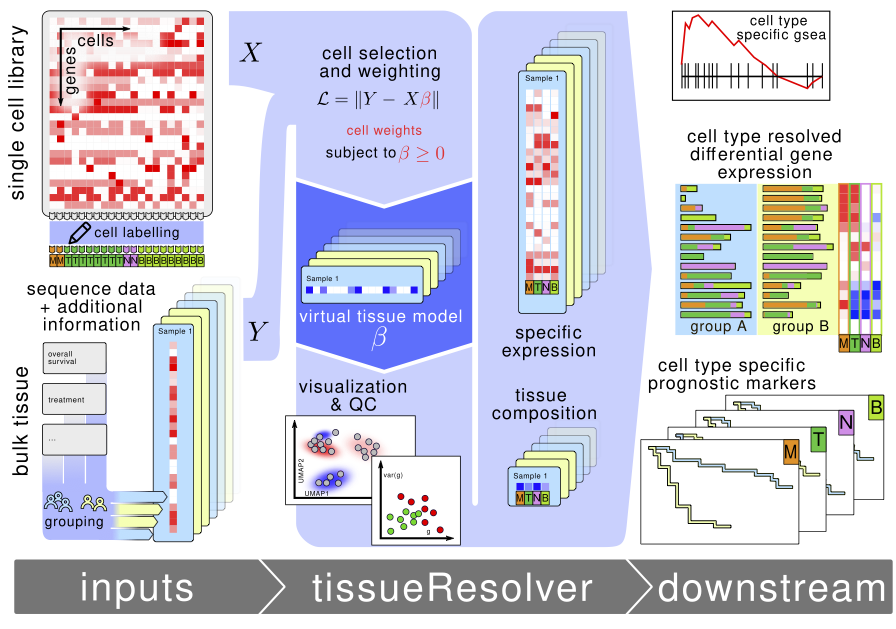

```r
knitr::include_graphics("schematics.png")
```

# Modules

Let us explain the modular architecture of `tissueResolver`, for more details see also the documentation of our package available under tissueResolver.

## Computation

- `fit_tissue`: Here the given single cell library is fitted to the bulk data by computing optimal cell weights $\beta$, see Compute Tissuemodel.
- `cell_proportions`: Here we use the cell weights computed in `fit_tissue` in order to determine weights for user defined cell groups, see Specific Expression and Proportions. These groups can for example describe certain cell types, such as B-cells, monocytes, T-cells, etc, but also user defined clusters resulting from a classical clustering workflow as depicted in Single Cell Clustering.
- `specific_expression`: Here we focus on computing the specific gene expression and regulation for all of the above defined cell groups, see Specific Expression and Proportions.
- `util`: This module comprises some utility functions, e.g., for checking input data for correct formatting or for transforming input data into the correct format.

## Quality control

- `quality_scores`: Here we compute all the quality scores needed to assess the quality of the fit, see Quality Scores. The main quality scores are:
  - the genewise mean relative residual $g_g := \frac{1}{N_s N_k} \sum_{s,k} r_{g,s}^{k}$
  - the genewise mean bootstrap variance $v_g := \frac{1}{N_s}\sum_s \mathrm{var}_k r_{g,s}^{k}$
  - the samplewise mean relative residual $b_s = \frac{1}{N_g N_k} \sum_{g,k} r_{g,s}^{k}$
  - the genewise mean bootstrap variance $v_s := \frac{1}{N_g N_k} \sum_{g,k} r_{g,s}^{k}$

## Data Visualization

- `weight_visualization`: Here we visualize the single cells involved in the fitting process in UMAP space, after prior PCA embedding of their profiles, together with the assigned weights as a density plot illustrating the differential density between two bulk groups, see Data visualization.
- `cse_visualization`: Here we visualize the differential gene expression of two bulk groups in the form of relative bar plots and a heatmap plot tracking down differential expression to the cell cluster level, see Relative Barplots and Heatmap.
- `prop_visualization`: Here we depict the ratio of cumulated weights between two bulk groups for each cell cluster, see Cell Weight Proportions.

For in depth explanations of the modules and the functions they comprise we refer to the respective documentation in tissueResolver There we also provide simple examples working with easy to access (artificial) data for ease of presentation.

In this vignette we want to give a more general overview over the most important functions used when building a practical `tissueResolver` pipeline. Here we use the actual real bulk and single cell data, that was also analyzed in our paper.  
This means running the following code will reproduce large parts of the results presented in our paper. For all results not contained in this vignette we provide additional R scripts, see also `README.md`.

We note that the data comprised in `bulks.rds` and `sc.rds` is the result of the gene filtering procedure explained in supplemental section **Gene filtering** of our paper. We mainly filter for the top 1000 most variable genes in both bulk and single cell data sets.

So let us enter the `tissueResolver` pipeline.  
First of all we load the `tissueResolver` package and further necessary libraries.

```r
  library(tissueResolver)
  library(tidyverse)
  library(Seurat)
  library(umap)
  library(viridis)
  library(gridExtra)
  source("map_feature_names.R")
  set.seed(42)
```

# Data Loading

```r
# we initialized data dir in the repo
data_dir <- "data"
plotdir <- file.path(data_dir, "plots")
dir.create(plotdir, showWarnings = FALSE)
```

All the upcoming calculations are based on the collection of bulk samples `bulks.rds` and the single cell library `sc.rds`.

```r
  if (!file.exists(file.path(data_dir, "sc.rds")) || !file.exists(file.path(data_dir,"bulks.rds"))){
     stop("Single cell or bulk data missing. Please provide sc.rds and bulks.rds in your data folder.")
  } else {
    sc <- readRDS(file.path(data_dir, "sc.rds"))
    bulks <- readRDS(file.path(data_dir,"bulks.rds"))
  }
```

Let’s explore the single cell dataset.

```r
  names(sc)
```

```
#> [1] "sc.counts"          "sc.normalization"   "sc.feature.id.type"
#> [4] "sc.pheno"
```

```r
  # number of genes:
  dim(sc$sc.counts)[1]
```

```
#> [1] 1000
```

```r
  # number of cells:
  dim(sc$sc.counts)[2]
```

```
#> [1] 63700
```

```r
  # excerpt of counts
  sc$sc.counts[100:110,3:4]
```

```
#>                 tFL2_AAATGCCGTAGCACGA tFL2_AACCATGGTACCAGTT
#> ENSG00000035403               0.00000                0.0000
#> ENSG00000251562             669.92174             2369.4772
#> ENSG00000205542             999.88319              328.7136
#> ENSG00000019582             159.98131               27.3928
#> ENSG00000156508             204.97605              136.9640
#> ENSG00000166710             704.91765             1451.8184
#> ENSG00000075624             439.94861              342.4100
#> ENSG00000087086              14.99825               13.6964
#> ENSG00000204287              39.99533                0.0000
#> ENSG00000162078               0.00000                0.0000
#> ENSG00000244734               0.00000                0.0000
```

```r
  # the celltypes as annotated in the original publications
  # together with the number of corresponding cells
  sc$sc.pheno %>% group_by(celltype) %>% summarize(n_cells = n())
```

| celltype | n_cells |
| --- | --- |
| B | 13595 |
| NK | 248 |
| Plasmablasts | 122 |
| T_CD4 | 6534 |
| T_CD8 | 9385 |
| T_reg | 3089 |
| Tfh | 3771 |
| Th1 | 3441 |
| malignant_lymphoma | 22604 |
| monocyte | 567 |
| myeloid | 224 |
| unknown | 120 |

Let’s explore the bulk dataset.

```r
  names(bulks)
```

```
#> [1] "bulk.counts"          "bulk.normalization"   "bulk.feature.id.type"
#> [4] "bulk.pheno"
```

```r
  # number of genes:
  dim(bulks$bulk.counts)[1]
```

```
#> [1] 1000
```

```r
  # number of bulk samples:
  dim(bulks$bulk.counts)[2]
```

```
#> [1] 481
```

```r
  # excerpt of bulk samples
  bulks$bulk.counts[1:10,1:5]
```

```
#>                  DLBCL10502  DLBCL10521 DLBCL11255  DLBCL11256  DLBCL11257
#> ENSG00000148848 0.048216158 0.000000000 0.03905428 0.029408065  0.21697980
#> ENSG00000182492 3.435363809 2.160265882 0.21343028 0.441043155  4.89310196
#> ENSG00000245848 0.707511235 0.414346729 0.30552905 0.529656766  1.16923121
#> ENSG00000197467 0.007377262 0.002111614 0.00109802 0.002680284  0.05976832
#> ENSG00000084636 0.156634562 0.083929898 0.12326961 0.072377354  1.37778667
#> ENSG00000108821 6.417632547 9.842983417 3.14774298 1.917288226 83.86056586
#> ENSG00000164692 3.305625979 2.875126249 1.81873731 1.297065852 54.36261826
#> ENSG00000130635 0.600532347 0.661966355 0.14217374 0.056022180  3.38151571
#> ENSG00000204262 0.454389170 0.403115320 0.39579634 0.224165249  4.44364554
#> ENSG00000142173 1.531140371 4.727215046 1.37954466 1.691845244 13.48537266
```

```r
  # the genetic ABC/GCB subtype labeling from the original publication
  bulks$bulk.pheno %>% group_by(Gene.Expression.Subgroup) %>% summarize(n_samples = n())
```

| Gene.Expression.Subgroup | n_samples |
| --- | --- |
| ABC | 243 |
| GCB | 138 |
| Unclass | 100 |

This genetic subtype will be used for the grouping of bulks, see Retrieving Bulk Groups.

# Compute Tissuemodel

This section is dedicated to illustrate the module `fit_tissue` which implements the steps explained in section **Algorithm** of our paper. Due to the high dimensional constrained optimization problem which has to be solved in every bootstrap run this function needs some computation time. Therefore we provide the tissuemodel as a `.rds` file. However, we provide the option for the bulks to be fit in parallel in order to speed up the computation.

```r
  bootstrap <- TRUE
  bootstrap_nruns <- 50
  bootstrap_pctcells <- 10
  # allow for high iteration number in order for optimizer to converge
  maxit <- 2e3
  # for fitting bulks in parallel specify here the number of CPU cores
  ncores <- 1

  if (file.exists(file.path(data_dir,"tissuemodel.rds"))){
    tissuemodel <- readRDS(file.path(data_dir,"tissuemodel.rds"))
  } else {
      tissuemodel <- fit_tissue(
                      bulkdata = bulks$bulk.counts,
                      sclibrary = sc$sc.counts,
                      maxit = maxit,
                      bootstrap = bootstrap,
                      bootstrap_nruns = bootstrap_nruns,
                      bootstrap_pctcells = bootstrap_pctcells,
                      ncores = ncores
                  )
      saveRDS(tissuemodel, file.path(data_dir, "tissuemodel.rds"))
  }
```

So let’s explore the tissuemodel.

```r
  # the model's parameters for overview:
  names(tissuemodel)
```

```
#> [1] "bootstrap"          "bootstrap_nruns"    "bootstrap_pctcells"
#> [4] "bootstrap_ncells"   "tissuemodels"       "log_stores"
#> [7] "fitted_genes"
```

```r
  # the first tissuemodels resulting from the bootstrap runs
  head(tissuemodel$tissuemodels[[1]], n=10)
```

| bulk_id | cell_id | weight |
| --- | --- | --- |
| DLBCL10502 | CCAATCCAGTACCGGA_DLBCL008NB | 0.0502247 |
| DLBCL10502 | CACCACTGTTGCGCAC_DLBCL008B | 0.0294722 |
| DLBCL10502 | DLBCL1_GAATAAGTCACTATTC | 0.0101278 |
| DLBCL10502 | TGCCCATCAGTGGGAT_DLBCL008B | 0.0061160 |
| DLBCL10502 | TCGCGTTAGGTAAACT_DLBCL008B | 0.0040257 |
| DLBCL10502 | GCACTCTCATGCCTAA_DLBCL111NB | 0.0119550 |
| DLBCL10502 | DLBCL2_CAGAGAGAGTTAGCGG | 0.0013262 |
| DLBCL10502 | tFL2_CGAATGTTCTTTAGTC | 0.0804596 |
| DLBCL10502 | CGACTTCCAAGCTGAG_FL3NB | 0.0056419 |
| DLBCL10502 | CTGTTTAGTAAACCTC_DLBCL008B | 0.0020402 |

```r
  head(tissuemodel$tissuemodels[[2]], n=10)
```

| bulk_id | cell_id | weight |
| --- | --- | --- |
| DLBCL10502 | tFL2_ACGGAGATCACTATTC | 0.0248820 |
| DLBCL10502 | ACACCGGGTGGCCCTA_FL2NB | 0.0069839 |
| DLBCL10502 | AGGCCGTCACCACGTG_FL2B | 0.0053101 |
| DLBCL10502 | DLBCL1_CCTAGCTGTCTAGCGC | 0.0230240 |
| DLBCL10502 | AGGGATGGTGCTAGCC_FL3NB | 0.0023324 |
| DLBCL10502 | DLBCL1_GGGCATCAGATGAGAG | 0.0325549 |
| DLBCL10502 | CAGCTGGGTACCGCTG_DLBCL007B | 0.0119682 |
| DLBCL10502 | CGCGTTTTCAATCACG_DLBCL111NB | 0.0163889 |
| DLBCL10502 | GTAACGTTCAAGGTAA_DLBCL008B | 0.0247192 |
| DLBCL10502 | TAGTGGTGTCTCTCGT_DLBCL002NB | 0.0071151 |

The tissuemodel also stores logging info about the iterations of the optimizer, here exemplarily for the first bootstrap run and a specific bulk sample.

```r
  tissuemodel$log_stores[[1]] %>% filter(bulk_id == "DLBCL10502") %>% pull(log)
```

```
#> [[1]]
#>  [1] "iter   10 value 85135.774673" "iter   20 value 60947.280196"
#>  [3] "iter   30 value 53761.596784" "iter   40 value 49414.116687"
#>  [5] "iter   50 value 46456.107052" "iter   60 value 44402.333156"
#>  [7] "iter   70 value 42753.476206" "iter   80 value 41278.975912"
#>  [9] "iter   90 value 40358.371719" "iter  100 value 39624.166404"
#> [11] "iter  110 value 38845.511046" "iter  120 value 38142.950052"
#> [13] "iter  130 value 37828.875975" "iter  140 value 37369.406317"
#> [15] "iter  150 value 36948.665148" "iter  160 value 36567.727774"
#> [17] "iter  170 value 36282.531493" "iter  180 value 35815.546106"
#> [19] "iter  190 value 35616.405195" "iter  200 value 35477.061323"
#> [21] "iter  210 value 35334.614457" "iter  220 value 35087.731998"
#> [23] "iter  230 value 34968.611891" "iter  240 value 34831.470358"
#> [25] "iter  250 value 34738.166534" "iter  260 value 34499.953825"
#> [27] "iter  270 value 34405.790011" "iter  280 value 34367.908943"
```

[output cut: 21 more lines]

Now we determine how many cells were drawn on average and the corresponding standard deviation.

```r
  all_models <- tibble()

  for (irun in 1:bootstrap_nruns) {
      all_models <- rbind(all_models, tissuemodel$tissuemodels[[irun]] %>% add_column(run = irun))
  }

  all_models_drawn <- all_models %>%
      group_by(bulk_id, run) %>%
      summarize(ncells = n()) %>%
      ungroup() %>%
      group_by(bulk_id) %>%
      mutate(mean_ncells = mean(ncells))

  ncells_mean_bulk <- unique(all_models_drawn$mean_ncells)

  # cells drawn on avarage
  mean(ncells_mean_bulk)
```

```
#> [1] 25.44118
```

```r
  # standard deviation
  sd(ncells_mean_bulk)
```

```
#> [1] 5.383898
```

So we see that on average in order to declare a bulk 25 cells were drawn with a standard deviation of 5.

# Retrieving Bulk Groups

Here we simply retrieve the grouping comprised in the original bulk data annotations and save it to a `.csv` file. In our publication this grouping reflects the ABC vs. GCB genetic subtype of DLBCL patients.

```r
  if (file.exists(file.path(data_dir, "grouping.csv"))) {
      grouping <- as_tibble(read.csv(file.path(data_dir, "grouping.csv")))
  } else {
      # get the bulk group labels
      bulkpheno <- as_tibble(bulks$bulk.pheno)
      # write to csv
      grouping <- tibble(
          bulk_id = bulkpheno[["colnames"]],
          group = bulkpheno[["Gene.Expression.Subgroup"]]
      )
      write_csv(grouping, file.path(data_dir, "grouping.csv"))
  }

  head(grouping)
```

| bulk_id | group |
| --- | --- |
| DLBCL11202 | Unclass |
| DLBCL10484 | GCB |
| DLBCL10555 | GCB |
| DLBCL10942 | Unclass |
| DLBCL10566 | Unclass |
| DLBCL10549 | GCB |

# Computing Cell-type Specific Expression

One of our main goals is to see how *cell types* or *cell clusters* explain regulatory processes within bulk tissues. Thus, we need to compute from the tissuemodel’s weights, which were computed independently of any cell type labels, the cell frequencies, cell type specific expression and regulation, see section **Cell frequencies and cell-type specific gene expression from virtual tissues** of our paper.

In order to compute these quantities, we first need to define a mapping that maps each cell to a certain cell type or cluster. Our downstream analysis focuses on cell clusters rather than originally labeled cell types, as this will reveal novel insights into known signatures.

These clusters we will compute now.

## Single Cell Clustering

As explained in supplementary section **Clustering of single cells** of our paper, we use a standard Seurat workflow to arrive at granular cell clusters complementing the cell type labels from the original studies.

```r
# PCA hyperparameters
npca <- 15
resolution <- 0.5

# retrieve original celltype labels
origtypes <- sc$sc.pheno %>% pull(celltype)
diagnosis <- sc$sc.pheno %>% pull(diagnosis)
tissue <- sc$sc.pheno %>% pull(Tissue)
subclass <- sc$sc.pheno %>% pull(Subclassification)

# Seurat workflow for computing PCA
seurobj <- CreateSeuratObject(counts = sc$sc.counts, min.cells = 3, min.features = 5)
seurobj <- ScaleData(seurobj, features = rownames(seurobj))
seurobj <- RunPCA(seurobj, features = rownames(seurobj))

# label according to diagnosis for final UMAP plot
diagnosis <- replace_na(diagnosis, "Reactive Lymphadenitis")
diagnosis[diagnosis == "Diffuse large B cell lymphoma"] <- subclass[diagnosis == "Diffuse large B cell lymphoma"]
names(diagnosis) <- sc$sc.pheno %>% pull(colnames)
seurobj@meta.data[["diagnosis"]] <- diagnosis[rownames(seurobj@meta.data)]

seurobj@meta.data[["diagnosis"]] <- replace(seurobj@meta.data[["diagnosis"]], seurobj@meta.data[["diagnosis"]] == "FL", "Follicular Lymphoma")
seurobj@meta.data[["diagnosis"]] <- replace(seurobj@meta.data[["diagnosis"]], seurobj@meta.data[["diagnosis"]] == "tFL", "Transformed Follicular Lymphoma")
seurobj@meta.data[["diagnosis"]] <- replace(seurobj@meta.data[["diagnosis"]], seurobj@meta.data[["diagnosis"]] == "non-Germinal Center subtype", "ABC DLBCL")
seurobj@meta.data[["diagnosis"]] <- replace(seurobj@meta.data[["diagnosis"]], seurobj@meta.data[["diagnosis"]] == "Germinal Center subtype", "GCB DLBCL")
```

In the next step we cluster our PCA embedded single cell data via Louvain clustering.

```r
# cluster the PCA embedded cells
seurobj <- FindNeighbors(seurobj, dims = 1:npca)
seurobj <- FindClusters(seurobj, resolution = resolution)
```

## Visualization of Single Cell Clusters

In order to visualize the clusters we have just computed we apply UMAP and plot the result, see also the UMAP figure of our paper.

Note that due to the randomness inherent to UMAP clustering the plot depends on the system it is executed on, but the cluster labels as stored in `seurobj@meta.data` stay consistent.  
These labels will be used for downstream analysis and will thus be stored in `clustering.csv`, see below.

```r
# perform UMAP embedding
seurobj <- RunUMAP(seurobj, dims = 1:npca)

umap_diagnosis <-
    DimPlot(seurobj,
      reduction = "umap",
      group.by = "diagnosis",
      cols = c("#2a2ab57e", "#ff8400b5", "#cd0000b7", "#059405a1", "#cb4e05b5"),
      label = FALSE
    )

ggsave(
    file = file.path(plotdir, "umap_diagnosis.png"),
    umap_diagnosis,
    width = 12,
    height = 12,
    dpi = 150,
    units = "in",
    device = "png"
)
```

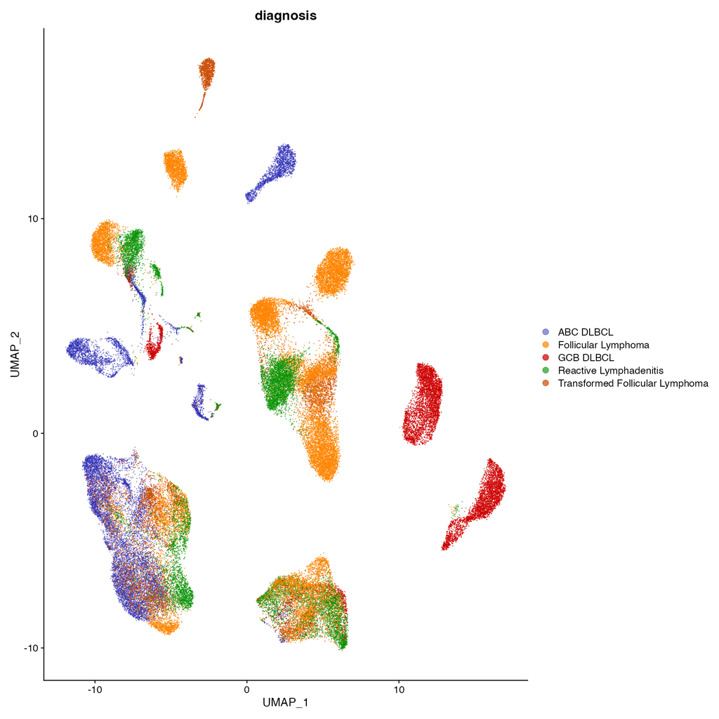

```r
knitr::include_graphics(file.path(plotdir,"umap_diagnosis.png"))
```

Exemplarily we see several large B-cell clusters reflecting different patients.

For downstream analysis we store the resulting clustering

```r
# for later use we store the clustering to a .csv file
if (file.exists(file.path(data_dir, "clustering.csv"))) {
  clustering <- read.csv(file.path(data_dir, "clustering.csv"))
} else {
  clustering <- seurobj@meta.data %>%
    rownames_to_column() %>%
    as_tibble() %>%
    rename(clusters = seurat_clusters)

  write_csv(clustering, file.path(data_dir, "clustering.csv"))
}
```

## Specific Expression and Proportions

With the clusters at hand we can now compute the cell type specific expression and proportions which encode the cell type frequencies, see also section **Cell frequencies and cell-type specific gene expression from virtual tissues** of our paper. But first we need to map each cell to its corresponding cluster.

```r
# construct cell type mapping based on the single cell clusters
mapping <- sc$sc.pheno %>%
    dplyr::select(colnames, celltype) %>%
    rename(cell_id = colnames)
mapping <- mapping %>%
  inner_join(clustering %>% rename(cell_id = rowname))

# the cellidentity we use are given by the clusters computed above
cellidentity <- "clusters"
mapping <- mapping %>%
    dplyr::select(cell_id, all_of(cellidentity)) %>%
    rename(celltype = all_of(cellidentity))
```

Now we are in the position to compute specific expression and regulation. All these quantities are included in the `csre` dataframe, see also the documentation of `specific_expression_regulation` for details.

Note that due to its high dimensionality computing `csre` is the most cost intensive task in our pipeline.  
Thus, we provide this dataframe as `.rds` file.

```r
if(file.exists(file.path(data_dir, "csre.rds"))){
  csre <- readRDS(file.path(data_dir,"csre.rds"))
} else {
  csre <- tissueResolver::specific_expression_regulation(tissuemodel, sc$sc.counts, mapping)
  saveRDS(csre, file.path(data_dir, "csre.rds"))
}
```

So let us have a look at this dataframe.

```r
  dim(csre)
```

```
#> [1] 10582000        7
```

```r
  csre %>% filter(bulk_id == "DLBCL11205", celltype == "1",  gene == "ENSG00000156508")
```

| bulk_id | celltype | gene | expression_boot | regulation_boot | expression | regulation |
| --- | --- | --- | --- | --- | --- | --- |
| DLBCL11205 | 1 | ENSG00000156508 | 340.7035, 461.7135, 502.0794, 345.4883, 459.2286, 452.9536, 437.9851, 379.2407, 439.3252, 391.8864, 524.7250, 453.2041, 436.5204, 328.9854, 414.1274, 380.9569, 357.3656, 358.3912, 409.7072, 491.4106, … | 1511.780, 1727.541, 1606.259, 1374.963, 1596.421, 1537.957, 1738.847, 1565.382, 1571.743, 1536.190, 1715.240, 1492.688, 1420.340, 1416.579, 1446.187, 1452.232, 1635.649, 1547.287, 1572.919, 1657.416, … | 431.6251 | 1558.502 |

We see that this dataframe stores for each bulk all the bootstrap cell-type specific expressions and regulations, as well as their mean across all bootstrap runs.

Furthermore we compute the cell proportions, i.e., the cell type weights resulting from cumulating the weights across all cells belonging to a certain celltype and then averaging over bootstrap runs.

```r
if(file.exists(file.path(data_dir, "proportions.rds"))){
  props <- readRDS(file.path(data_dir, "proportions.rds"))
} else {
  props <- tissueResolver::cell_proportions(tissuemodel, mapping)
  saveRDS(props, file.path(data_dir, "proportions.rds"))
}
```

So let us have a look at this dataframe.

```r
  dim(props)
```

```
#> [1] 9131    4
```

```r
  props %>% filter(bulk_id == "DLBCL11205", celltype == "1")
```

| bulk_id | celltype | weight_boot | weight |
| --- | --- | --- | --- |
| DLBCL11205 | 1 | 0.2253658, 0.2672664, 0.3125768, 0.2512710, 0.2876612, 0.2945164, 0.2518825, 0.2422672, 0.2795146, 0.2551028, 0.3059193, 0.3036160, 0.3073351, 0.2322394, 0.2863581, 0.2623252, 0.2184855, 0.2316256, 0.… | 0.2770022 |

We see that this dataframe indeed associates to each cell-type in each bulk the weights of all bootstrap runs, as well as the average weight across bootstrap runs. In order to retrieve the sample specific *effective cell frequency* as in equation (2) of our paper, one additionally needs to divide by the sum over all weights belonging to this sample.

# Data Visualization

The goal of this section is to visualize differential gene expression of the already computed cell clusters in UMAP space via a tile overlay, see also the UMAP figure in our paper.

We invoke the `density_distribution` function in order to compute this tile overlay based on a density estimate for the cell’s weights, see also the documentation for details.

```r
# group according to genetic subtype
groupA <- "GCB"
groupB <- "ABC"

# recall already computed UMAP embedding for consistent visualization
embedding <- seurobj[["umap"]]@cell.embeddings
embedding <- tibble(cell_id = rownames(embedding), UMAP1 = embedding[, 1], UMAP2 = embedding[, 2])
# add celltype to embedding
embedding <- embedding %>%
  inner_join(sc$sc.pheno %>%
  dplyr::select(colnames, celltype) %>%
  rename(cell_id = colnames), by = "cell_id")

# take only the actual tissuemodels from the output of fit_tissue
tissuemodel <- tissuemodel$tissuemodels

# compute cumulated weights across bootstrap runs
tm <- tibble()
for (i in 1:length(tissuemodel)) {
    tm <- rbind(tm, tissuemodel[[i]] %>% add_column(bootid = i))
}
tissuemodel <- tm %>%
    group_by(bulk_id, cell_id) %>%
    summarise(weight = sum(weight), n = length(.data[["weight"]]), .groups = "keep")

# take only those cells contained in the embedding
thistm <- tissuemodel %>% filter(cell_id %in% (embedding %>% pull(cell_id)))
```

After these preparatory steps we are in the position to compute the density distribution and then plot the aforementioned tile plot.

```r
if(file.exists(file.path(data_dir, "density.rds"))){
  density_data <- readRDS(file.path(data_dir, "density.rds"))
} else {
  density_data <- tissueResolver::density_distribution(embedding, tissuemodel = thistm, bulkgroups = grouping)
  saveRDS(density_data, file.path(data_dir, "density.rds"))
}
```

After computing the differential density we can plot it in combination with the UMAP embedding

```r
plot_celltypes <- tissueResolver::plot_differential_densities(density_data,
                                  scembedding = embedding,
                                  groupA=groupA,
                                  groupB=groupB,
                                  embedding.x = "UMAP1",
                                  embedding.y = "UMAP2",
                                  colourby="celltype")
ggsave(file.path(plotdir,"umap_differential_celltypes.png"), plot_celltypes, width = 12, height = 12, dpi = 150, units = "in")
```

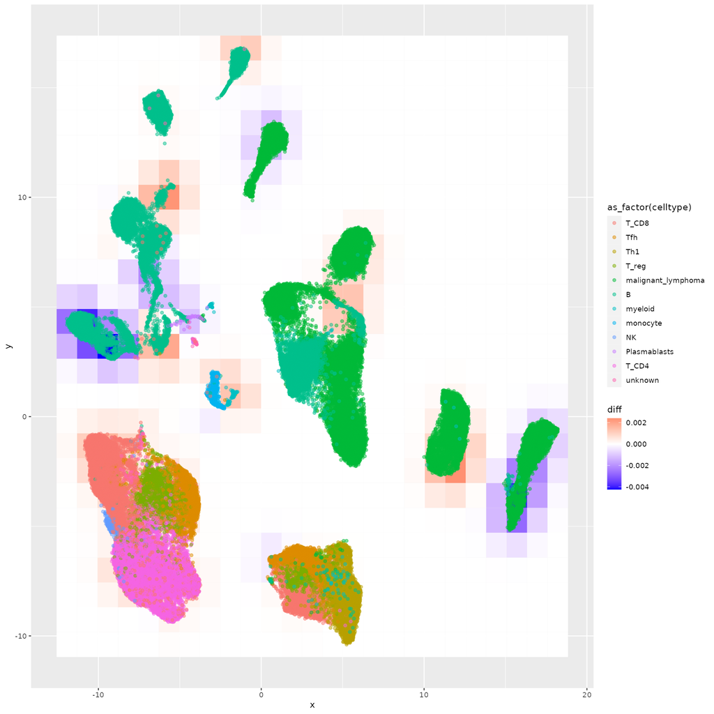

```r
knitr::include_graphics(file.path(plotdir,"umap_differential_celltypes.png"))
```

The tile overlay reveals both differentiality in the large B-cell clusters as well as intra cluster heterogeneity when comparing the ABC vs. GCB subtype. Red indicates that the cells in this area are in relation preferably associated to the GCB group whereas blue indicates drawing in favour of the ABC group. We see e.g., that most of the large B-cell clusters are drawn in favor of the patient group they were extracted from.

# Quality Scores

We now assess the quality of the fits via the quantities stored in `csre`. In `quality_scores` we compute the gene-specific and bulk-specific scores introduced in the paper, see section **Quality scores and gene selection**.

```r
if(file.exists(file.path(data_dir,"qc.rds"))){
  qc <- readRDS(file.path(data_dir,"qc.rds"))
} else {
  qc <- tissueResolver::quality_scores(csre, bulks$bulk.counts)
  saveRDS(qc,file.path(data_dir,"qc.rds"))
}

dim(qc)
```

```r
names(qc)
```

```
#> [1] "genes" "bulks"
```

```r
head(qc$genes)
```

| gene | relres_sample_var | relres | relres_mean_var | expression | bulk_expression |
| --- | --- | --- | --- | --- | --- |
| ENSG00000002586 | 0.0177990 | 0.2751211 | 0.0200843 | 3.2917597 | 3.326638 |
| ENSG00000002834 | 0.0175627 | 0.6087471 | 0.0262979 | 1.2566414 | 5.511996 |
| ENSG00000004534 | 0.0310462 | 0.4671529 | 0.0365088 | 0.8696547 | 2.518056 |
| ENSG00000005022 | 0.0190226 | 0.2297889 | 0.0060947 | 11.7801443 | 9.446720 |
| ENSG00000005844 | 0.0274253 | 0.5643468 | 0.0367116 | 0.8035266 | 3.161506 |
| ENSG00000007312 | 0.0247211 | 0.2720285 | 0.0145947 | 9.0796009 | 10.325600 |

We see that `qc` stores the quality scores for genes in `qc$genes` and the quality scores for bulks in `qc$bulks`. Furthermore it saves the actual bulk expression of each gene for convenient plotting.

Now we can exemplarily plot the mean relative residual $g_g$ vs. the mean bootstrap variance $v_g$.

```r
p_gene_mean_var_all <- qc$genes %>% ggplot(aes(x = relres, y = relres_mean_var)) +
  geom_point() +
  xlab("g_g") +
  ylab("v_g") +
  theme(
    axis.text = element_text(size = 12),
    axis.title = element_text(size = 20, face = "bold")
  )
ggsave(file.path(plotdir, "relres_relres_mean_var.png"), p_gene_mean_var_all, width = 10, height = 10)
```

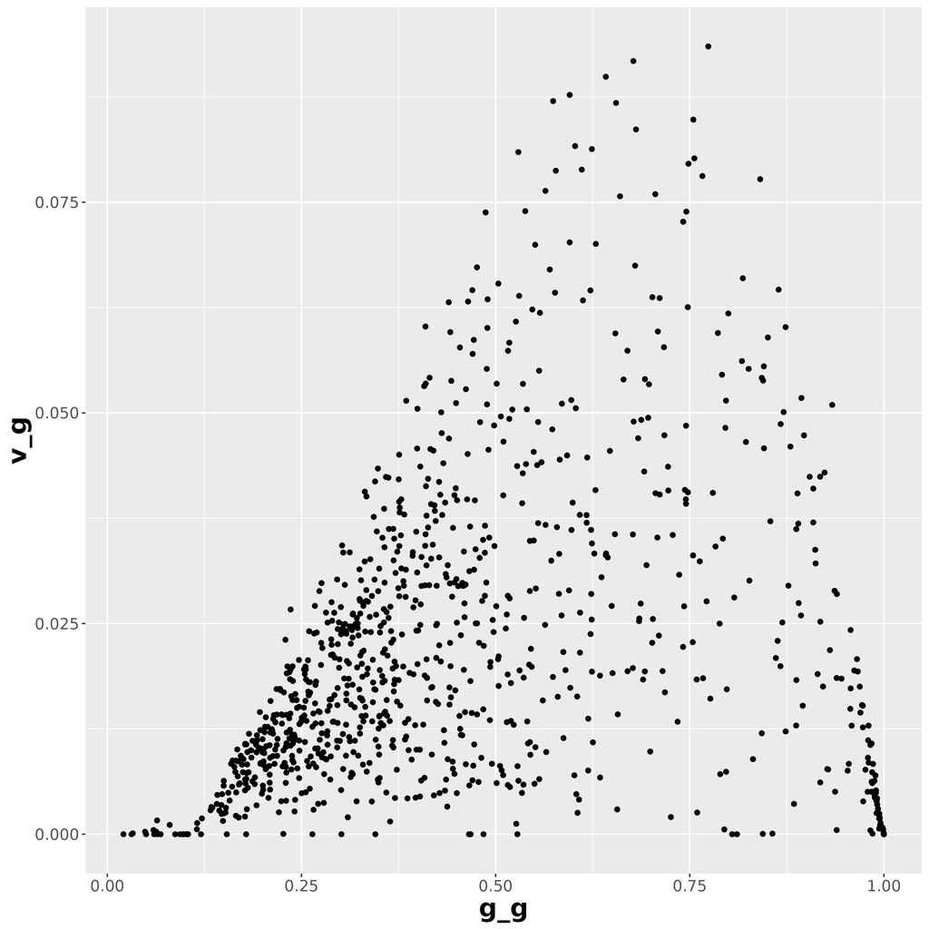

```r
knitr::include_graphics(file.path(plotdir, "relres_relres_mean_var.png"))
```

We see that most of the genes possess a low relative residual ($g_g\le 0.5$) and low bootstrap variance ($v_g\le 0.03$).

# CSRE Visualization

## Relative Barplots and Heatmap

In this section we visualize the cell type specific differential expression for the ABC/GCB bulk groups via a combined bar and heatmap plot, see section **The micro-environment of diffuse large B-cell lymphomas** of our paper.

First let us define the signature genes of the ABC/GCB signature from [Alizadeh et al., 2000](https://www.nature.com/articles/35000501).

```r
  # ABC/GCB signature genes
additional_genes <- c(
                "ENSG00000143727",
                "ENSG00000156127",
                "ENSG00000171791",
                "ENSG00000118971",
                "ENSG00000213923",
                "ENSG00000160213",
                "ENSG00000121966",
                "ENSG00000156136",
                "ENSG00000196937",
                "ENSG00000033170",
                "ENSG00000125166",
                "ENSG00000125245",
                "ENSG00000236418",
                "ENSG00000225890",
                "ENSG00000232062",
                "ENSG00000228284",
                "ENSG00000206305",
                "ENSG00000196735",
                "ENSG00000282657",
                "ENSG00000211899",
                "ENSG00000137265",
                "ENSG00000143772",
                "ENSG00000170421",
                "ENSG00000135363",
                "ENSG00000277443",
                "ENSG00000185697",
                "ENSG00000083454",
                "ENSG00000137193",
                "ENSG00000102096",
                "ENSG00000115956",
                "ENSG00000196396",
                "ENSG00000162924",
                "ENSG00000122026",
                "ENSG00000155926",
                "ENSG00000079263",
                "ENSG00000269404",
                "ENSG00000128040",
                "ENSG00000196628",
                "ENSG00000198467",
                "ENSG00000035403"
  )
  # retrieve groups stored in the grouping.csv
  grouping <- as_tibble(read.csv(file.path(data_dir, "grouping.csv")))
  grouping <- grouping %>% mutate(group = factor(group, levels=c(groupA, groupB)))
```

Accessing the `csre` dataframe we can plot the differential gene expression comparing both groups.

```r
  # take only signature genes
  csre <- csre %>% filter(gene %in% additional_genes)

  # map csre genes to HGNC symbols
    mapping <- map_feature_names(
      csre %>% pull(gene),
      input.type = "ensembl_gene_id",
      output.type = "hgnc_symbol",
      n.tries = 10,
      undo.safety.check = TRUE
    )
    mapvec <- mapping[["hgnc_symbol"]]
    names(mapvec) <- mapping[["ensembl_gene_id"]]
    csre <- csre %>%
      rename(ensembl = gene) %>%
      mutate(gene = mapvec[ensembl])

  # join grouping in order to be accessed by plot function
  csre <- csre %>% inner_join(grouping %>% dplyr::select(bulk_id, group)) %>% drop_na()

  p <- tissueResolver::plot_csre(csre,
    heatmapviz = "relchange",
    barplotviz = "relative",
    groupA = groupA,
    groupB = groupB,
    ctypes = NULL,
    addexpressionlevel = FALSE
    )
  ggsave(file.path(plotdir, "bar_heatmap_gcbabc.png"),
    p,
    width = 12,
    height = 12,
    dpi = 150,
    units = "in"
  )
```

So let us plot the relative change.

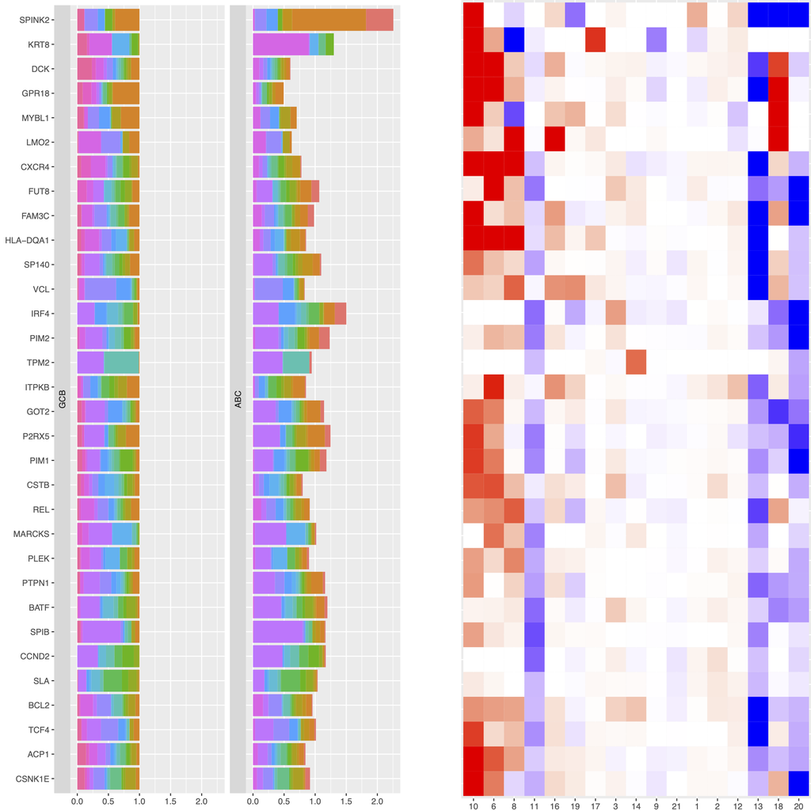

```r
knitr::include_graphics(file.path(plotdir, "bar_heatmap_gcbabc.png"))
```

The barplots on the left are normalized to the total explained expression of `groupA` namely the GCB subgroup. Thus, all the bars in this group possess length one and we can read the relative change from the bars in groupB. So e.g., the gene SPINK2 is more than two times upregulated in the ABC group with an intense change induced by clusters 18 and 20, which are represented by the brown and salmon color.

The heatmap plot further underlines gene expression changes by displaying the relation

```
0.5*(avgexpr_A-avgexpr_B)/(total_expr_A+total_expr_B),
```

where `avgexpr` denotes the average expression of the respective gene within the specific cluster in the associated bulk group and `total_expr` denotes the total explained expression of the gene in the associated bulk group.  
So the blue tiles for gene SPINK2 in cluster 18 and 20 stand for upregulation of that gene in the ABC bulk group.

## Cell Weight Proportions

Finally we want to plot the ratio of weights between bulk groups for each cluster, see the estimated cellular composition plot in the paper and also the documentation of `prop_visualization`.

Recall that the cumulated cell type specific weights are stored in the `props` dataframe. In `prop_visualization` we compute the mean of these cell type specific weights with repsect to the associated bulk group and further compute the standard error in order to assess the variability across samples symbolized by a whisker.

```r
grouping <- as_tibble(read.csv(file.path(data_dir, "grouping.csv")))
props <- readRDS(file.path(data_dir, "proportions.rds"))
prop_plot <- tissueResolver::prop_visualization(props, grouping, groupB, groupA)
ggsave(file.path(plotdir, "proportions.png"), prop_plot, width = 12, height = 12, dpi = 150, units = "in")
```

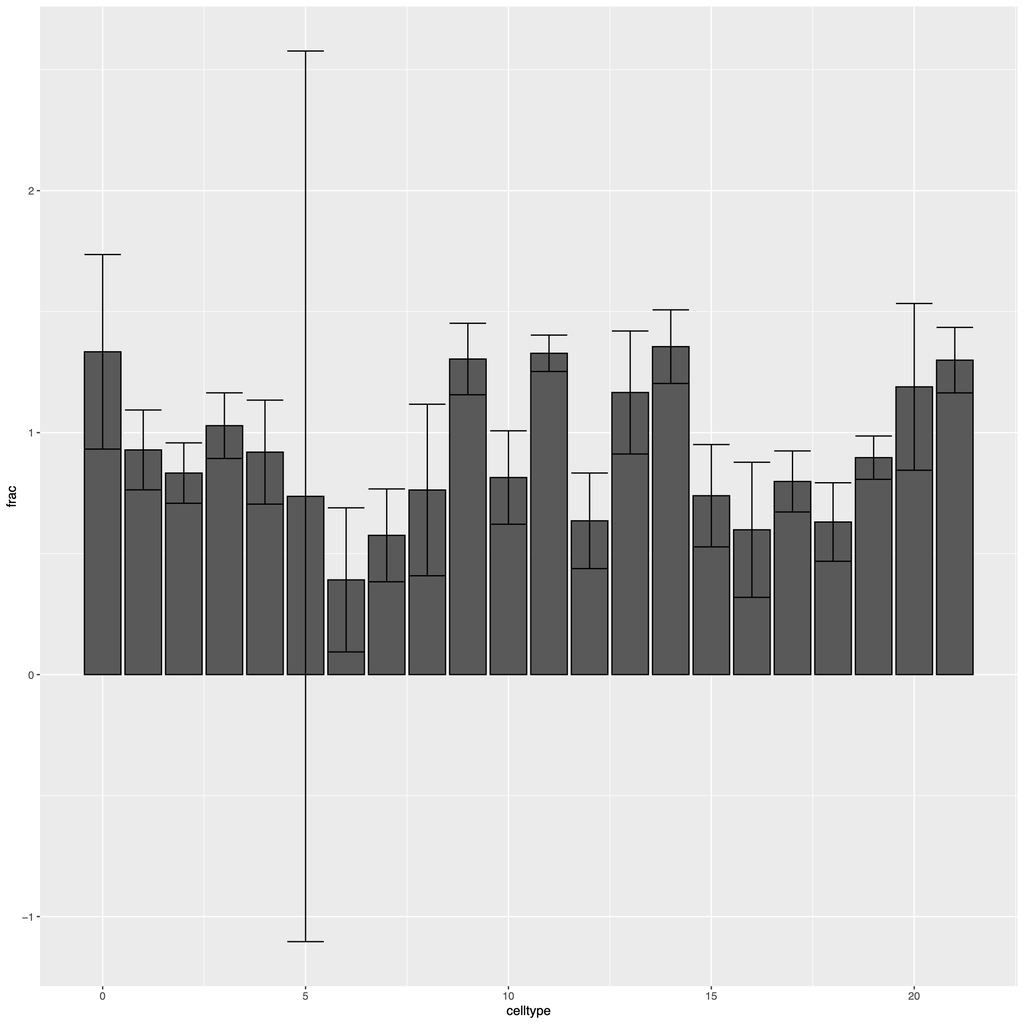

```r
knitr::include_graphics(file.path(plotdir, "proportions.png"))
```

For e.g., for cluster 17 we see that cells were *consistently* drawn in order to declare bulks indicated by a low variability in the plot’s whisker. The cell type specific weights assigned for GCB bulks are a bit higher than for ABC bulks in cluster 17.

In order to reproduce the remaining parts of our paper, we refer to the `R` scripts contained in this repository.